# project1

Szymon Berdzik

30/11/2021

```r
library(sp)
library(rgdal)
library(dbscan)
setwd('/home/szymon/Documents/nauka_agh/semestr5/adp/projekt1')
getwd()
```

```
## [1] "/home/szymon/Documents/nauka_agh/semestr5/adp/projekt1"
```

Zamiana współrzędnych wgs na ETRS 1989 Poland CS2000 Zone 7 z pliku zestaw1.

```r
df <- read.csv("zestaw1.csv")
cords.WGS = SpatialPoints(cbind(df$Long,df$Lat), proj4string=CRS("+proj=longlat"))
cords.UTM = spTransform(cords.WGS, CRS("+init=epsg:2178"))
df <- as.data.frame(cords.UTM)
names(df) <- c('Long', 'Lat')
head(df)
```

```
##      Long     Lat
## 1 7420912 5549067
## 2 7430922 5548966
## 3 7423426 5545805
## 4 7418870 5548418
## 5 7423844 5547124
## 6 7423639 5548253
```

Wczytanie pliku osiedla.shp

```r
osiedla <- readOGR(dsn='osiedla.shp', p4s="+init=epsg:2178")
osiedla$WSP_X <- coordinates(osiedla)[,1]
osiedla$WSP_Y <- coordinates(osiedla)[,2]
osiedla_df <- as.data.frame(osiedla)
head(osiedla_df)
```

```
##   GESTOSC_ZA ID IL_K_MOBIL IL_K_NIEMO IL_K_POPRO IL_K_PROD IL_K_PRZED
## 0        654  1        410        171        141       581        210
## 1        156  2        236         89         99       325        128
## 2        183  3         31         11         16        42         18
## 3         34  4         10          3          4        13          5
## 4        406  5        433        156        109       589        225
## 5        600  6        265        115         92       380        125
##   IL_L_MOBIL IL_L_NIEMO IL_L_POPRO IL_L_PROD IL_L_PRZED IL_M_MOBIL IL_M_NIEMO
## 0        824        378        246      1202        437        414        207
## 1        494        210        171       704        259        258        121
## 2         64         28         27        92         29         33         17
## 3         16          9          6        25          9          6          6
## 4        886        354        183      1240        492        453        198
## 5        540        250        160       790        250        275        135
##   IL_M_POPRO IL_M_PROD IL_M_PRZED ILOSC_K_10 ILOSC_KOBI ILOSC_MEZC ILOSC_MIES
```

[output cut: 20 more lines]

```r
plot_krakow <- function(color, title){
    plot(osiedla, main=title)
    plot(cords.UTM, col=color, add=TRUE,  pch=16, cex=0.7 )
}
```

Mapa krakowa

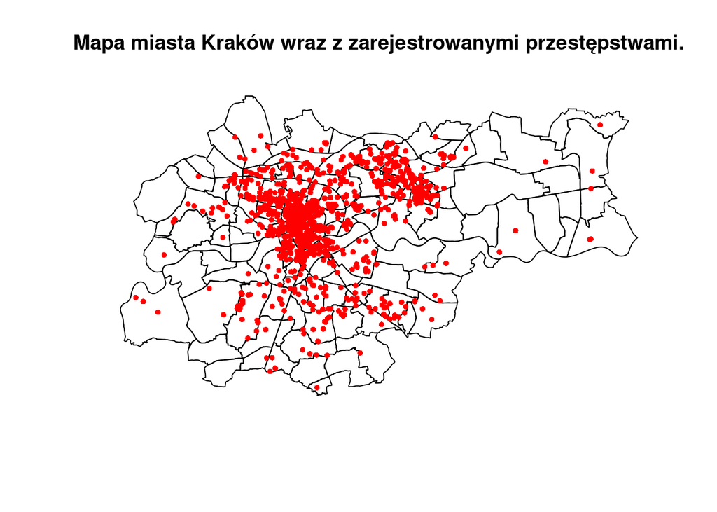

```r
plot_krakow(color='red', title="Mapa miasta Kraków wraz z zarejestrowanymi przestępstwami.")
```

Algorytm DBSCAN

Algorytm DBSAN jest to algorytm klasteryzacji przestrzennej w obecności szumu opartej na gęstości zjawisk. Grupuje razem punkty z wieloma pobliskimi sąsiadami, oznaczając jako punkty odstające, te które leżą samotnie w regionach o niskiej gęstości(którego najbliżsi sąsiedzi są zbyt daleko).Algorytm wymaga od użytkownika wprowadzenie dwóch parametrów (epsilon) oraz MinPts.

Wady: - Nie daje możliwości definiowania a priori liczby segmentów - liczba segmentów zależy od liczby obserwacji i dobranych parametrów. - Dobór odpowiednich parametrów bywa dosyć problematyczny - ich optymalizacja bywa długa i uciążliwa, gdyż nie ma jednej sprawdzonej metody.

Zalety: - Odporny na wpływ obserwacji odstających - Znakomicie radzi sobie z grupami o niewypukłym kształcie - Daje dobre rezultaty

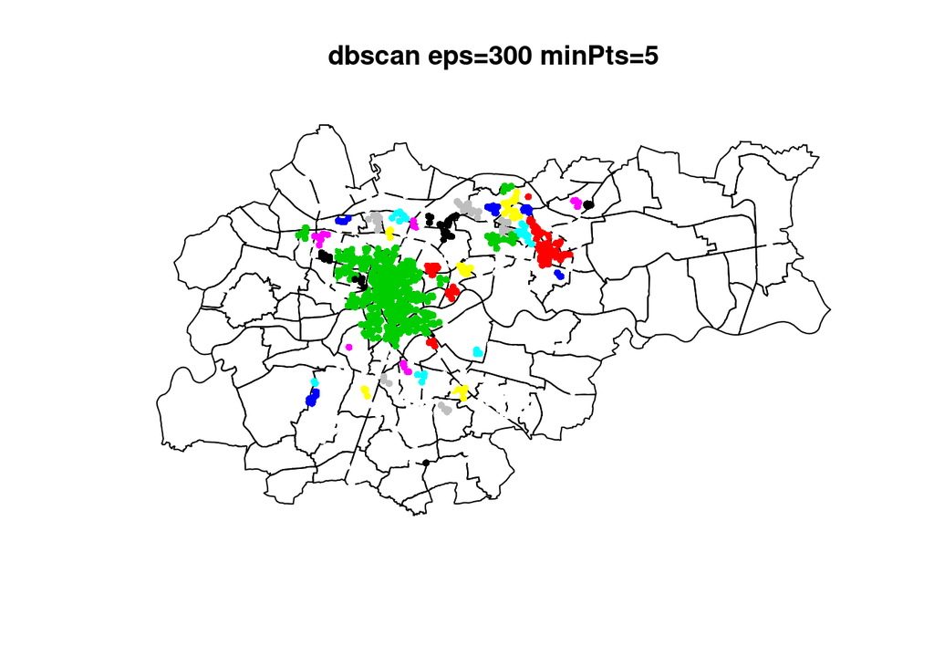

```r
dbscan_res1<-dbscan(df, eps=300, minPts=5)
plot_krakow(color=dbscan_res1$cluster, title="dbscan eps=300 minPts=5")
```

Można zauwazyć, że przy takich parametrach ukształtował nam sie jeden głowny klaster na terenie dzielnicy Starego Miasta/krowodrzy/grzegrzółki (zielony) oraz wiele małych klasterów. Uważam, że parametr minPts jest zbyt mały.

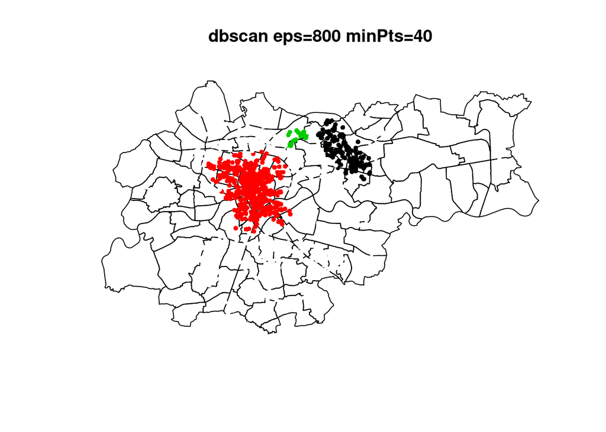

```r
dbscan_res1<-dbscan(df, eps=800, minPts=40)
plot_krakow(color=dbscan_res1$cluster, title="dbscan eps=800 minPts=40")
```

Zostaly utworzone 3 klastry: czerwony - Stare Miasto, Krowodorza, Grzegrzółki zielony - prądnik czerwony czarny - Bieńczyce/Mistrzejowice

Wyniki wydają się realne, obserwując mape można zauważyć, że w tych okolicach wykroczen jest najwiecej. Przetestujmy jeszcze opcje ze zmiejszeniem argumentu minPts.

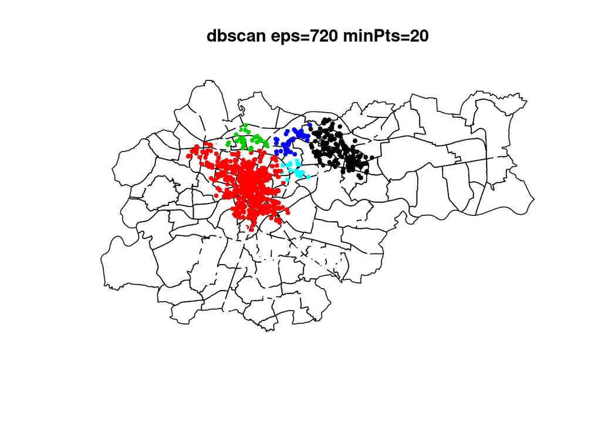

```r
dbscan_res1<-dbscan(df, eps=720, minPts=20)
plot_krakow(color=dbscan_res1$cluster, title="dbscan eps=720 minPts=20")
```

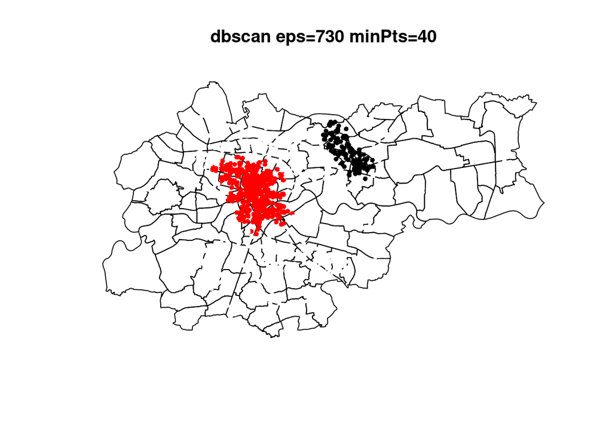

```r
dbscan_res1<-dbscan(df, eps=730, minPts=40)
plot_krakow(color=dbscan_res1$cluster, title="dbscan eps=730 minPts=40")
```

W tym przypadku zostały utworzone dwa klastry: czarny - Bienczyce i Mistrzejowice czerwony - Stare MIasto, Krowodorza, Grzegrzółki

Algorytm HDBSCAN

Algorytm HDBSCAN jest to algorytm hierarchicznej klasteryzacji przestrzennej w obecności szumu opartej na gęstości zjawisk, jest rozwinięciem algorytmu DBSCAN. Algorytm ten identyfikuje tzw. rdzenie klastrów jako te punkty, w sąsiedztwie których zlokalizowana jest wystarczająca ilość punktów sąsiadujących (większa bądź równa przyjętej wartości granicznej). Do tak zdefiniowanych rdzeni klastrów dołączane są punkty pozostające w bliskiej odległości od któregokolwiek z punktów rdzenia (bliżej niż zadana wartość), które w sumie tworzą klaster. Punkty niezakwalifikowane dożadnego klastra są określane jako szum.

Wady: - Nie daje możliwości definiowania a priori liczby segmentów - liczba segmentów zależy od liczby obserwacji i dobranych parametrów.

Zalety: - Odporny na wpływ obserwacji odstających - Pozwala stworzyć klastry o różnym kształcie - Wystarczy podać tylko jeden parametr - Porządkuje punkty w hierarchie klastrów w klastrach - umozliwia identyfikacje klastrów o róznych rozmiarach

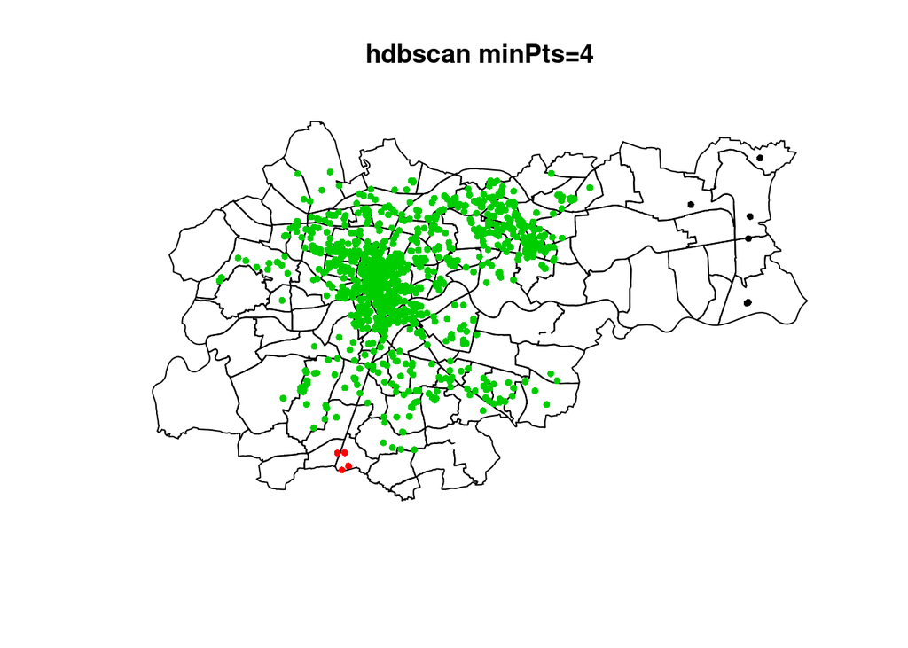

```r
hdbscan_res1<-hdbscan(df,minPts=4)
plot_krakow(color=hdbscan_res1$cluster, title="hdbscan minPts=4")
```

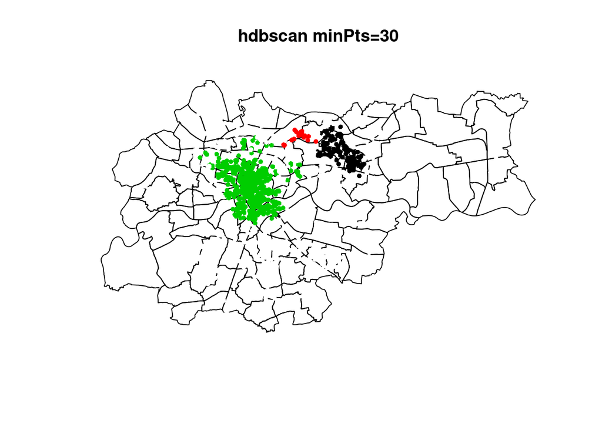

```r
hdbscan_res1<-hdbscan(df,minPts=30)
plot_krakow(color=hdbscan_res1$cluster, title="hdbscan minPts=30")
```

Zostaly utworzone 3 klastry: zielony - Stare Miasto, Krowodorza, Grzegrzółki czerwiby - prądnik czerwony czarny - Bieńczyce/Mistrzejowice

Są to wyniki podobne do wyników z algorytmu DBSCAN przy parametrach eps=800, minPts=40.

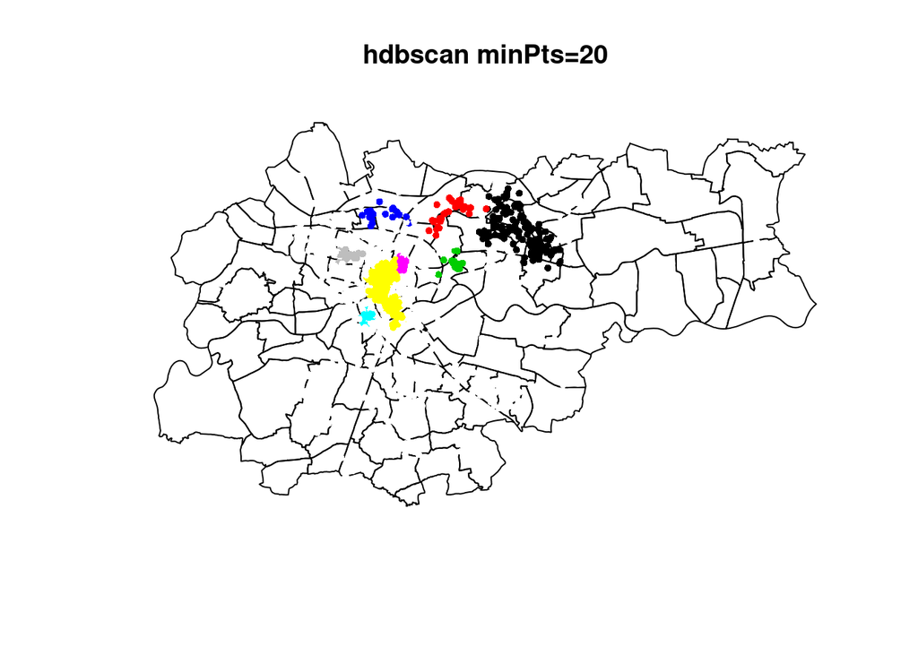

```r
hdbscan_res1<-hdbscan(df,minPts=20)
plot_krakow(color=hdbscan_res1$cluster, title="hdbscan minPts=20")
```

Otrzymalismy zbyt dużo klastrów. Słabo odnosi się to do naszych danych, aczkolwiek okolicje o zwiekszonej intensywnosci wykroczen jest dobra. Pierwszy Stare Miasto/Krowodorza/Grzegrzółki/Kazimierz oraz drugi Mistrzejowice/Bienczyce

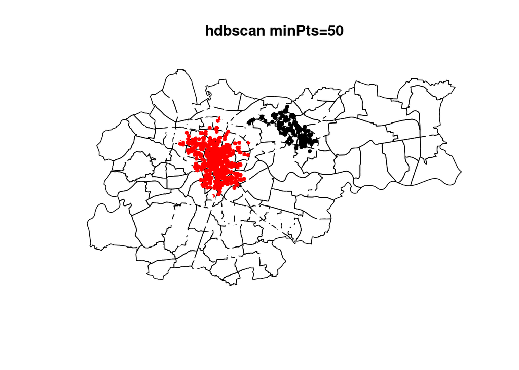

```r
hdbscan_res1<-hdbscan(df,minPts=50)
plot_krakow(color=hdbscan_res1$cluster, title="hdbscan minPts=50")
```

Zostały utworzone dwa klastry. Są to okolice o najwiekszej ilości odnotowanych wykroczeń na terenie Krakowa.

czarny - Bienczyce i Mistrzejowice czerwony - Stare MIasto, Krowodorza, Grzegrzółki

ALGORYTM OPTICS

Algorytm OPTICS jest to algorytm wyszukiwania klastrów opartych na gęstości w danych przestrzennych. Jego podstawowa idea jest podobna do DBSCAN, ale rozwiazuje jedną z głównych słabości tegi algorytmu: problem wykrywania znaczących klastrów w danych o różnej gęstości.W tym celu punkty bazy danych są (liniowo) uporządkowane w taki sposób, że najbliższe przestrzennie punkty stają się sąsiadami w porządkowaniu. Dodatkowo dla każdego punktu reprezentującego gęstość, która musi być zaakceptowana dla klastra, przechowywana jest specjalna odległość, aby oba punkty należały do tego samego klastra. Jest to reprezentowane jako dendrogram.

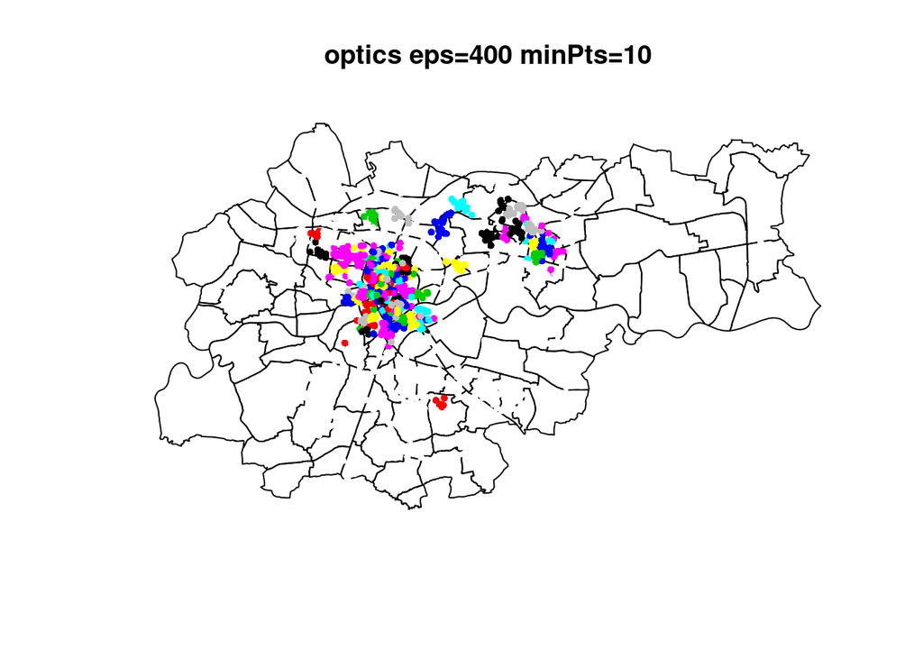

```r
optics_res1<-extractXi(optics(df, eps=400, minPts=10), xi=0.01)
plot_krakow(color=optics_res1$cluster, title="optics eps=400 minPts=10")
```

Przy parametrach eps=400 i minPts=10 możemy zaobserwowac podział na bardzo dużo małych klastrów w okolicach zmożonej intensywnosci zarejestrowanych wykroczeń.

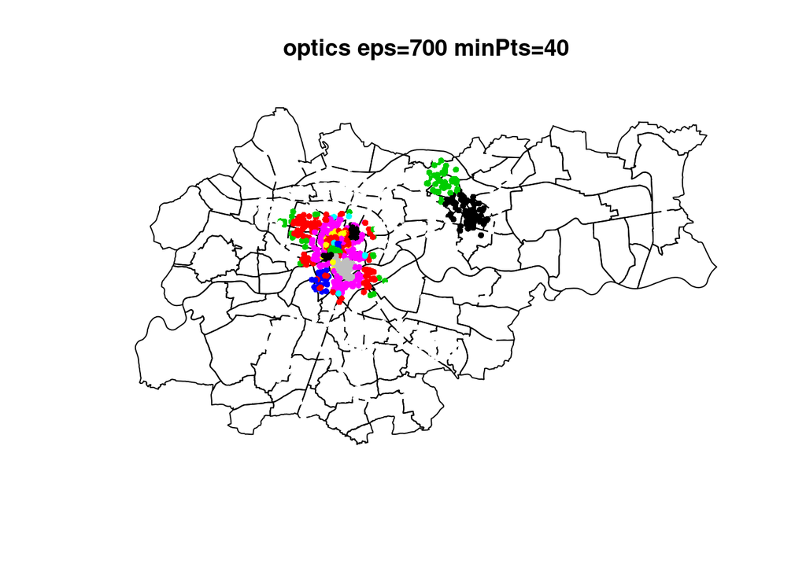

```r
optics_res1<-extractXi(optics(df, eps=700, minPts=40), xi=0.01)
plot_krakow(color=optics_res1$cluster, title="optics eps=700 minPts=40")
```

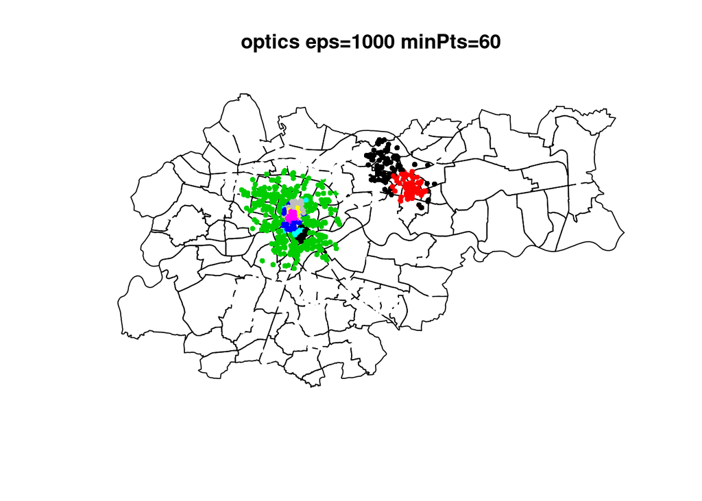

```r
optics_res1<-extractXi(optics(df, eps=1000, minPts=60), xi=0.01)
plot_krakow(color=optics_res1$cluster, title="optics eps=1000 minPts=60")
```

Powstały 3 duze klastry czerwony - Bieńczyce czarny - Mistrzejowice Zielony - Stare MIasto bez Rynku, Krowodrza, Grzegrzółki Mozna zauwazyć ze Rynek Głowny oraz prawdopodobnie okolice Kazimierza zostały rodzielone na kilka mniejszych klastrów, nie zostały dołączone do klastra koloru zielonego.

Podsumowując wyniki z zastosowania algorytmow DBSCAN i HDBSCAN były w miare podobne i dążyły do utworzenia 2/3 głównych klastrów, natomiast wyniki działania algorytmu OPTICS okazały się zupełnie inne, wystepuje to podział na wiekszą ilość klastrów(bardziej szczegółowy).